# WordPress Agents Exploratory Analysis- Part I- Univariate description

Viviane Schneider

09/07/2019

**Type of Analysis:** Descriptive analysis - Univariate description

**Intention of Analysis**: 1- Understand how Core WordPress Community coproduce code. 2- Identify potential indicators for coherence analysis.

**General Question:** *Wich are the atributes of coproduction (colunms of dataframe or variables)?* **Specific Questions:** *Which type of developers groups exist in WC? It is possible to make some indicator from this data?*

**Source:** Data come from WordPress Report Trac System. URL Source **Dataframe:** [GitHub Repository](https://raw.githubusercontent.com/vivianesch/CoherenceAnalysisWordPress/master/TicketW.csv)

**Date collection:** 04/07/2019.

**1.GENERAL ANALYSIS**

```r
#READ DATA
library(readr)
library(dplyr)
```

```r
library(plotly)
TicketW <- read_csv('~/PhD Analysis/1. PhD escriptive exploratory analysis/TicketW.csv')
View(TicketW)
dim(TicketW) #dimension
```

```
## [1] 2333   16
```

```r
TicketW[1:5,]  #5 fist lines
```

```
## # A tibble: 5 x 16
##      id Summary Status Version Owner Type  Priority Milestone Component
##   <dbl> <chr>   <chr>  <lgl>   <chr> <chr> <chr>    <chr>     <chr>
## 1 24579 Add Dr~ new    NA      <NA>  enha~ high     Future R~ Upgrade/~
## 2 30361 Correc~ assig~ NA      pento task~ high     <NA>      General
## 3 32502 Cannot~ new    NA      <NA>  defe~ high     <NA>      Administ~
## 4 36441 Custom~ new    NA      <NA>  defe~ high     Future R~ Customize
## 5 40439 Save p~ assig~ NA      mike~ enha~ high     5.3       Media
## # ... with 7 more variables: Severity <chr>, Resolution <chr>,
## #   Created <chr>, Modified <chr>, Focuses <chr>, Reporter <chr>,
## #   Keywords <chr>
```

```r
summary(TicketW)
```

```
##        id          Summary             Status          Version
##  Min.   : 5235   Length:2333        Length:2333        Mode:logical
##  1st Qu.:34555   Class :character   Class :character   NA's:2333
##  Median :40511   Mode  :character   Mode  :character
##  Mean   :38029
##  3rd Qu.:44485
##  Max.   :47640
##     Owner               Type             Priority
##  Length:2333        Length:2333        Length:2333
##  Class :character   Class :character   Class :character
##  Mode  :character   Mode  :character   Mode  :character
##
##
##
##   Milestone          Component           Severity
##  Length:2333        Length:2333        Length:2333
##  Class :character   Class :character   Class :character
##  Mode  :character   Mode  :character   Mode  :character
##
##
##
##   Resolution          Created            Modified
##  Length:2333        Length:2333        Length:2333
##  Class :character   Class :character   Class :character
##  Mode  :character   Mode  :character   Mode  :character
##
##
##
##    Focuses            Reporter           Keywords
##  Length:2333        Length:2333        Length:2333
##  Class :character   Class :character   Class :character
##  Mode  :character   Mode  :character   Mode  :character
##
##
##
```

```r
glimpse(TicketW)
```

```
## Observations: 2,333
## Variables: 16
## $ id         <dbl> 24579, 30361, 32502, 36441, 40439, 41292, 41886, 41...
## $ Summary    <chr> "Add Drag'n'Drop UI to plugin and theme manual uplo...
## $ Status     <chr> "new", "assigned", "new", "new", "assigned", "reope...
## $ Version    <lgl> NA, NA, NA, NA, NA, NA, NA, NA, NA, NA, NA, NA, NA,...
## $ Owner      <chr> NA, "pento", NA, NA, "mikeschroder", "jnylen0", "me...
## $ Type       <chr> "enhancement", "task (blessed)", "defect (bug)", "d...
## $ Priority   <chr> "high", "high", "high", "high", "high", "high", "hi...
## $ Milestone  <chr> "Future Release", NA, NA, "Future Release", "5.3", ...
## $ Component  <chr> "Upgrade/Install", "General", "Administration", "Cu...
## $ Severity   <chr> "normal", "normal", "major", "normal", "normal", "n...
## $ Resolution <chr> NA, NA, NA, NA, NA, NA, NA, NA, NA, NA, NA, NA, NA,...
## $ Created    <chr> "06/14/2013 05:03:38 PM", "11/17/2014 12:10:55 PM",...
## $ Modified   <chr> "04/12/2019 11:04:54 AM", "06/04/2019 07:42:28 PM",...
## $ Focuses    <chr> NA, "ui, administration", NA, NA, "ui", NA, NA, NA,...
## $ Reporter   <chr> "tw2113", "pento", "ryan", "azaozz", "mikeschroder"...
## $ Keywords   <chr> "ui-feedback ux-feedback needs-patch shiny-updates"...
```

**1.1 Variables related with members Analysis** **Goal:** Find which variables have hight variability, and find a line of cut, in order to use into Bivariate Analysis.

```r
# Var1
Status<-table(TicketW$Status)
# Transform into table
Status<-as.data.frame(as.table(Status))
PropStatus<-prop.table(Status$Freq) #Proportion
Status<-data.frame(Status,PropStatus)

#Var2
TType<-table(TicketW$Type)
# Transform into table
TType<-as.data.frame(as.table(TType))
PropTType<-prop.table(TType$Freq) #Proportion
TType<-data.frame(TType,PropTType)

#Var3
Priority<-table(TicketW$Priority)
# Transform into table
Priority<-as.data.frame(as.table(Priority))
PropPrio<-prop.table(Priority$Freq) #Proportion
Priority<-data.frame(Priority,PropPrio)

#Var4
Milestone<-table(TicketW$Milestone)
# Transform into table
Milestone<-as.data.frame(as.table(Milestone))
PropMiles<-prop.table(Milestone$Freq) #Proportion
Milestone<-data.frame(Milestone,PropMiles)


#Var5
Component<-table(TicketW$Component)
# Transform into table
Component<-as.data.frame(as.table(Component))
c1<-Component[order(Component$Freq, decreasing = TRUE),]
Component = filter(Component, Freq>100)
sum(Component$Freq)
```

```
## [1] 647
```

```r
PropComp<-prop.table(Component$Freq) #Proportion
Component<-data.frame(Component,PropComp)


#Var6
Severity<-table(TicketW$Severity)
# Transform into table
Severity<-as.data.frame(as.table(Severity))
PropSever<-prop.table(Severity$Freq) #Proportion
Severity<-data.frame(Severity,PropSever)

#Var7
Focuses<-table(TicketW$Focuses)
# Transform into table
Focuses<-as.data.frame(as.table(Focuses))
f1<-Focuses[order(Focuses$Freq, decreasing = TRUE),]
Focuses = filter(Focuses, Freq>10)
PropFocus<-prop.table(Focuses$Freq) #Proportion
Focuses<-data.frame(Focuses,PropFocus)
sum(Focuses$Freq)
```

```
## [1] 832
```

```r
Keywords<-table(TicketW$Keywords)#Var8
# Transform into table
Keywords<-as.data.frame(as.table(Keywords))
k1<-Keywords[order(Keywords$Freq, decreasing = TRUE),]
Keywords = filter(Keywords, Freq>9)
Keywords = filter(Keywords, Freq>40)
Prop.Keyw<-prop.table(Keywords$Freq) #Proportion
Keywords<-data.frame(Keywords,Prop.Keyw)
sum(Keywords$Freq)
```

```
## [1] 761
```

**1.2 Variable Members Analysis - Reporters:** Reporters are WordPress Community members who find and report a problem from WP Platform, into a Ticket.

**Goal:** Find type of report member groups (actives, medians, and aliens), and find a line of cut, in order to use into Bivariate Analysis.

```r
# Transform into table
Reporter<-table(TicketW$Reporter)
Reporter<-as.data.frame(as.table(Reporter))
summary(Reporter)
```

```
##             Var1           Freq
##  _ck_         :   1   Min.   : 1.000
##  5um17        :   1   1st Qu.: 1.000
##  aaroncampbell:   1   Median : 1.000
##  abhijitrakas :   1   Mean   : 2.269
##  abletec      :   1   3rd Qu.: 2.000
##  AD7six       :   1   Max.   :72.000
##  (Other)      :1022
```

```r
totalReporter<-nrow(Reporter)

#1.2.1 Filter the most active group of reporters (Which reporter with more than 10 tickets)
ActiveReporters = filter(Reporter,Freq>10)
totalAR<-nrow(ActiveReporters) #Total members of active reporters group
RankAR <- ActiveReporters[order(ActiveReporters$Freq, decreasing = TRUE),]
summary(RankAR$Freq)
```

```
##    Min. 1st Qu.  Median    Mean 3rd Qu.    Max.
##   11.00   15.00   18.00   23.65   24.75   72.00
```

```r
#1.2.2 Filter the median active group of reporters (Which reporter with less than 10 tickets and more than 4 tickets)
MedianReporters = filter(Reporter,Freq<10 & Freq>4)
totalMR<-nrow(MedianReporters)
#Ranking the Median active reporters
RankMR <- MedianReporters[order(MedianReporters$Freq, decreasing = TRUE),]

#1.2.3 Filter the less active group of Report (Which reporter with less than 10 tickets)
LessReporters = filter(Reporter,Freq<4)
totalLR<-nrow(LessReporters)
#Ranking the less active Reporters
Ranklr <- LessReporters[order(LessReporters$Freq, decreasing = TRUE),]
```

**1.3 Variable Member Analysis - Owners:** Owners are WordPress Community members who pick up a ticket from WP Platform (sended by a reporter) in order to solve it.

**Goal:** Find type of owner member groups (actives, medians, and aliens), and find a line of cut, in order to use into Bivariate Analysis.

```r
# Transform into table
Owner<-table(TicketW$Owner)
Owner<-as.data.frame(as.table(Owner))
summary(Owner)
```

```
##               Var1          Freq
##  aaroncampbell  :  1   Min.   : 1.000
##  adam3128       :  1   1st Qu.: 1.000
##  adamsilverstein:  1   Median : 1.000
##  afercia        :  1   Mean   : 3.095
##  allisonplus    :  1   3rd Qu.: 2.000
##  antpb          :  1   Max.   :67.000
##  (Other)        :110
```

```r
totalOwner<-nrow(Owner)

# 1.3.1 Filter the most active group of Owners (Which Owner with more than 10 tickets)
ActiveOwner = filter(Owner,Freq>10)
totalAO<-nrow(ActiveOwner)
#Ranking the most active Owners
RankAO <- ActiveOwner[order(ActiveOwner$Freq, decreasing = TRUE),]

#1.3.2 Filter the median active group of Owners (Which Owner with less than 10 tickets and more than 4 tickets)
MedianOwner = filter(Owner,Freq<10 & Freq>4)
totalMO<-nrow(MedianOwner)
#Ranking the Median Owners
RankMO <- MedianOwner[order(MedianOwner$Freq, decreasing = TRUE),]

#1.3.3 Filter the less active group of Owners (Which Owner with less than 10 tickets)
LessOwner = filter(Owner,Freq<4)
totalLO<-nrow(LessOwner)
#Ranking the less active Owners
RanklO <- LessOwner[order(LessOwner$Freq, decreasing = TRUE),]
```

**1.4 Sum of groups by Reporters and Owners:**

```r
#Total members per Reporter
MembersTotalR<-c(totalReporter,totalAR,totalMR,totalLR)
CoreGroupR<-c("Reporters","Active Reporters","Median Reporters","Alien Reporters")
PropMR<-prop.table(MembersTotalR)# Proportion
WPCGroupR<-data.frame(CoreGroupR,MembersTotalR,PropMR)

#Total members per Owner
MembersTotalO<-c(totalOwner,totalAO,totalMO,totalLO)
CoreGroupO<-c("Owners","Active Owners","Median Owners","Alien Owners")
PropMO<-prop.table(MembersTotalO) #Proportion
WPCGroupO<-data.frame(CoreGroupO,MembersTotalO,PropMO)

PropMR-1
```

```
## [1] -0.4923457 -0.9832099 -0.9822222 -0.5422222
```

```r
PropMO-1
```

```
## [1] -0.4912281 -0.9736842 -0.9473684 -0.5877193
```

sim<-ifelse(PropMO>PropMR,1-(PropMO-PropMR)/4,1-(PropMR-PropMO)/4)

**2. DESCRIPTION ANALYSIS REPORT :**

```r
Status#Var1
```

```
##        Var1 Freq PropStatus
## 1  accepted   53 0.02271753
## 2  assigned  215 0.09215602
## 3       new 1844 0.79039863
## 4  reopened  116 0.04972139
## 5 reviewing  105 0.04500643
```

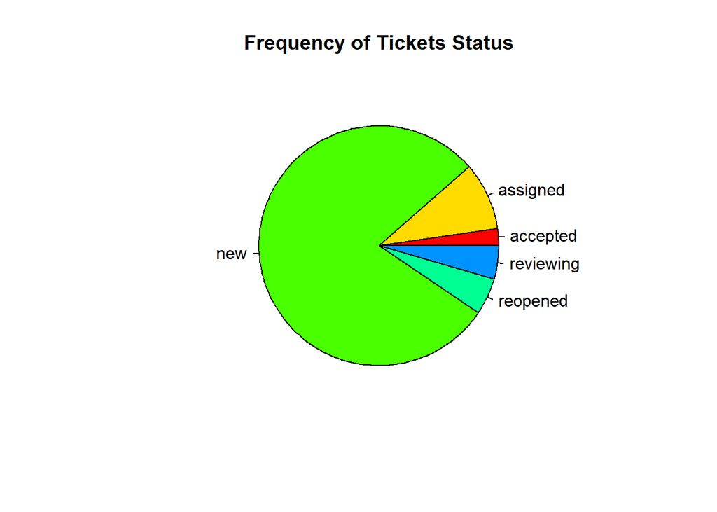

```r
#Graphics
pie(Status$Freq, main="Frequency of Tickets Status", label=Status$Var1, col = rainbow(7))
```

```r
TType# Var2
```

```
##              Var1 Freq  PropTType
## 1    defect (bug) 1012 0.43377625
## 2     enhancement 1109 0.47535362
## 3 feature request  168 0.07201029
## 4  task (blessed)   44 0.01885984
```

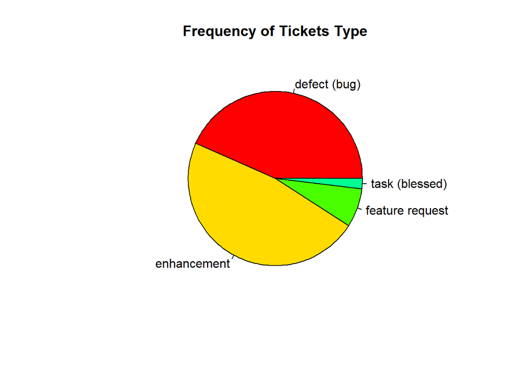

```r
#Graphics
pie(TType$Freq, main="Frequency of Tickets Type", label=TType$Var1, col = rainbow(7))
```

```r
Priority# Var3
```

```
##     Var1 Freq    PropPrio
## 1   high   12 0.005143592
## 2    low   49 0.021003000
## 3 lowest    7 0.003000429
## 4 normal 2265 0.970852979
```

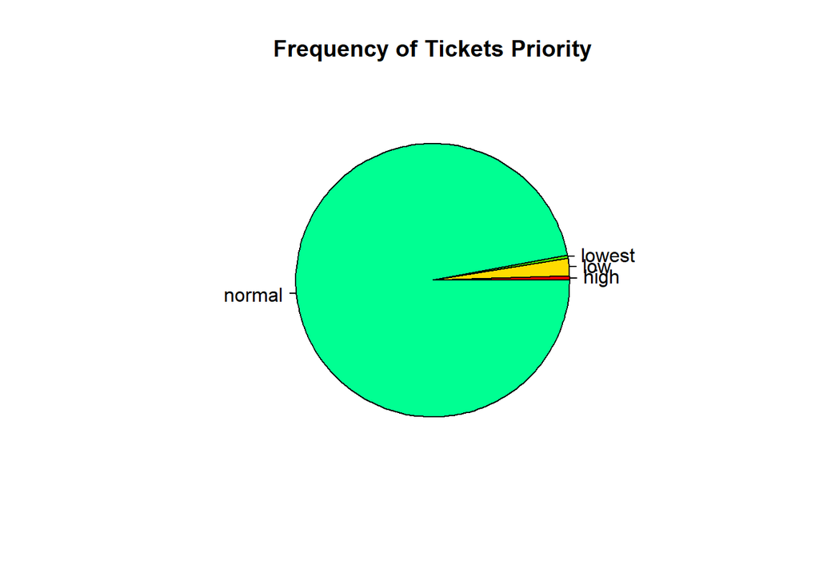

```r
#Graphics
pie(Priority$Freq, main="Frequency of Tickets Priority", label=Priority$Var1, col = rainbow(7))
```

```r
Milestone#Var4
```

```
##              Var1 Freq    PropMiles
## 1           5.2.3    1 0.0005452563
## 2             5.3  172 0.0937840785
## 3 Awaiting Review 1104 0.6019629226
## 4  Future Release  544 0.2966194111
## 5   WordPress.org   13 0.0070883315
```

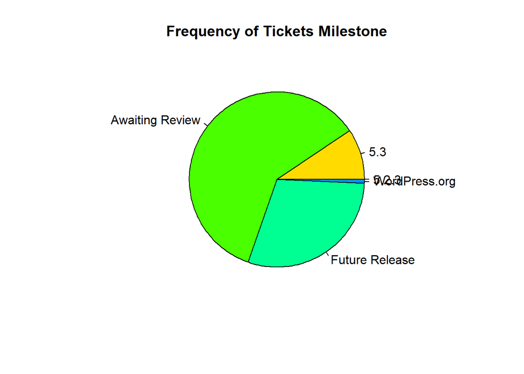

```r
#Graphics
pie(Milestone$Freq, main="Frequency of Tickets Milestone", label=Milestone$Var1, col = rainbow(7))
```

```r
Component#Var5
```

```
##                Var1 Freq  PropComp
## 1    Administration  162 0.2503864
## 2           General  205 0.3168470
## 3             Media  166 0.2565688
## 4 Posts, Post Types  114 0.1761978
```

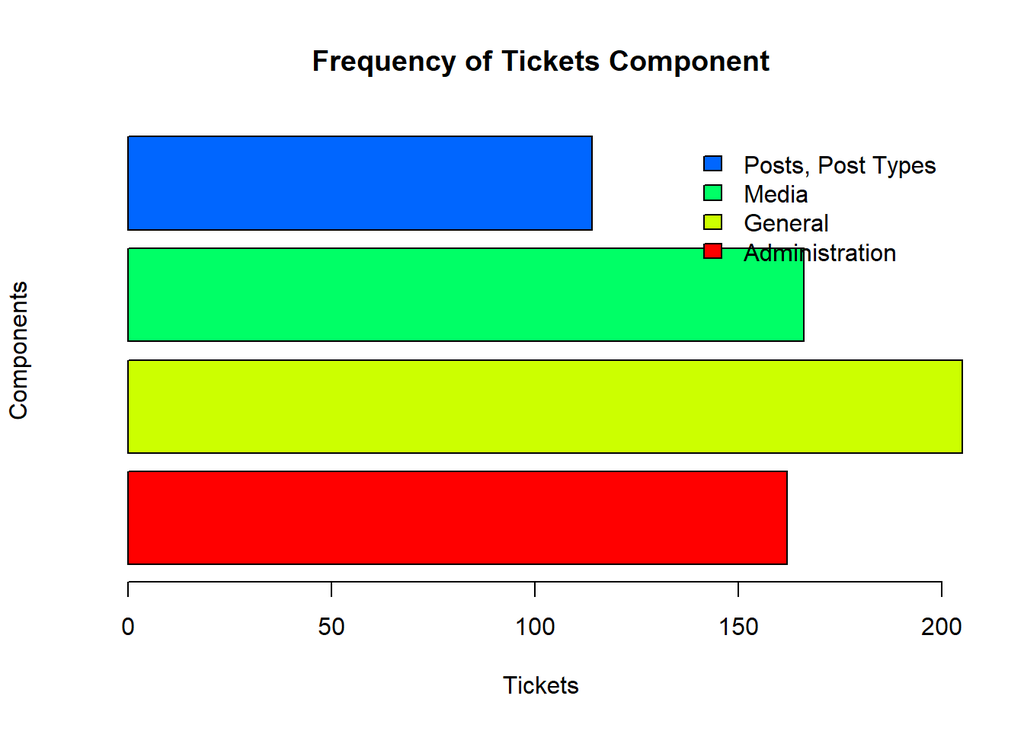

```r
#Graphics
barplot(Component$Freq,
        xlab = "Tickets",
        ylab = "Components",
        main="Frequency of Tickets Component",
        col = rainbow(5),
        legend.text = Component$Var1,
        horiz=TRUE,
        args.legend = list("bottom", bty="n", cex = 1))
```

```r
Severity #Var6
```

```
##       Var1 Freq    PropSever
## 1  blocker    1 0.0004286327
## 2 critical    9 0.0038576940
## 3    major   27 0.0115730819
## 4    minor   91 0.0390055722
## 5   normal 2186 0.9369909987
## 6  trivial   19 0.0081440206
```

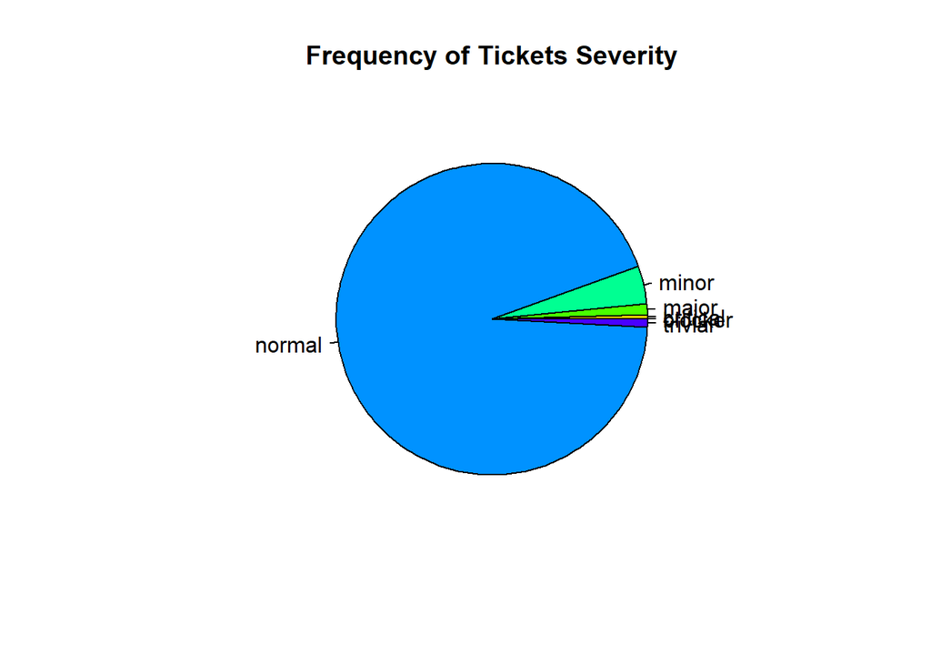

```r
#Graphics
pie(Severity$Freq, main="Frequency of Tickets Severity", label=Severity$Var1, col = rainbow(7))
```

```r
Focuses#Var7
```

```
##                  Var1 Freq  PropFocus
## 1       accessibility   23 0.02764423
## 2      administration  192 0.23076923
## 3    coding-standards   27 0.03245192
## 4                docs   58 0.06971154
## 5          javascript   49 0.05889423
## 6           multisite   95 0.11418269
## 7         performance   55 0.06610577
## 8            rest-api   30 0.03605769
## 9            template   48 0.05769231
## 10                 ui  103 0.12379808
## 11  ui, accessibility   51 0.06129808
## 12 ui, administration  101 0.12139423
```

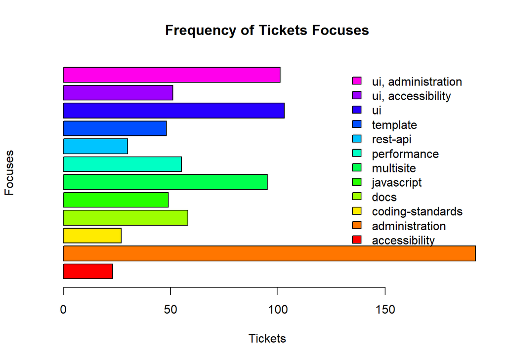

```r
#Graphics
barplot(Focuses$Freq,
        xlab = "Tickets",
        ylab = "Focuses",
        main="Frequency of Tickets Focuses",
        col = rainbow(13),
        legend.text = Focuses$Var1,
        horiz=TRUE,
       args.legend = list("bottom", bty="n", cex = 1))
```

```r
Keywords#Var8
```

```
##                           Var1 Freq  Prop.Keyw
## 1                  2nd-opinion   55 0.07227332
## 2                    has-patch  246 0.32325887
## 3      has-patch needs-refresh   47 0.06176084
## 4      has-patch needs-testing   44 0.05781866
## 5                  needs-patch  266 0.34954008
## 6 needs-patch needs-unit-tests   46 0.06044678
## 7            reporter-feedback   57 0.07490145
```

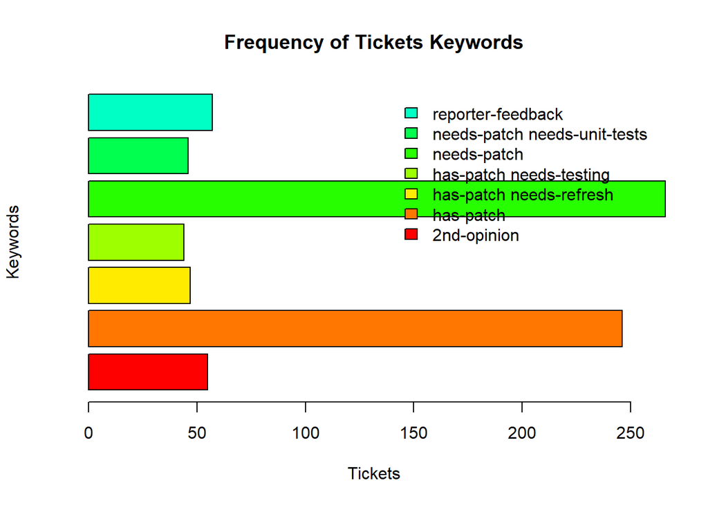

```r
#Graphics
barplot(Keywords$Freq,
        xlab = "Tickets",
        ylab = "Keywords",
        main="Frequency of Tickets Keywords",
        col = rainbow(13),
        legend.text = Keywords$Var1,
        horiz=TRUE,
        args.legend = list("bottom", bty="n", cex = 1))
```

**2.2 Reporter Members Analysis Report** The groups of Reporters:

```r
RankAR #Ranking the most active reporters
```

```
##                Var1 Freq
## 14      johnbillion   72
## 1           afercia   53
## 15  johnjamesjacoby   47
## 29 sebastian.pisula   43
## 9          flixos90   42
## 5   danielbachhuber   39
## 16       karmatosed   33
## 27           rmccue   27
## 31 subrataemfluence   25
## 34      westonruter   24
## 21            nacin   23
## 7           desrosj   22
## 10  garrett-eclipse   22
## 22           pbiron   22
```

[output cut: 20 more lines]

```r
RankMR #Ranking the Median active reporters
```

```
##              Var1 Freq
## 8       ericlewis    8
## 10        iandunn    8
## 14     jeremyfelt    8
## 18    joostdevalk    8
## 20         kjellr    8
## 25         netweb    8
## 26      pavelevap    8
## 28     programmin    8
## 1       alexvorn2    7
## 3            andy    7
## 7          eclare    7
## 9     Frank Klein    7
## 13       jdgrimes    7
## 27        pbearne    7
```

[output cut: 22 more lines]

```r
Ranklr[c(1:30),c(1:2)] #Ranking the 30 less active Reporters
```

```
##                  Var1 Freq
## 29           allendav    3
## 56              arena    3
## 138      chetan200891    3
## 140 chinteshprajapati    3
## 186          danieltj    3
## 201 Denis-de-Bernardy    3
## 210         diddledan    3
## 214           dimadin    3
## 234        dotancohen    3
## 249             duck_    3
## 288           fliespl    3
## 299             GaryJ    3
## 342       hlashbrooke    3
## 362          ishitaka    3
```

[output cut: 16 more lines]

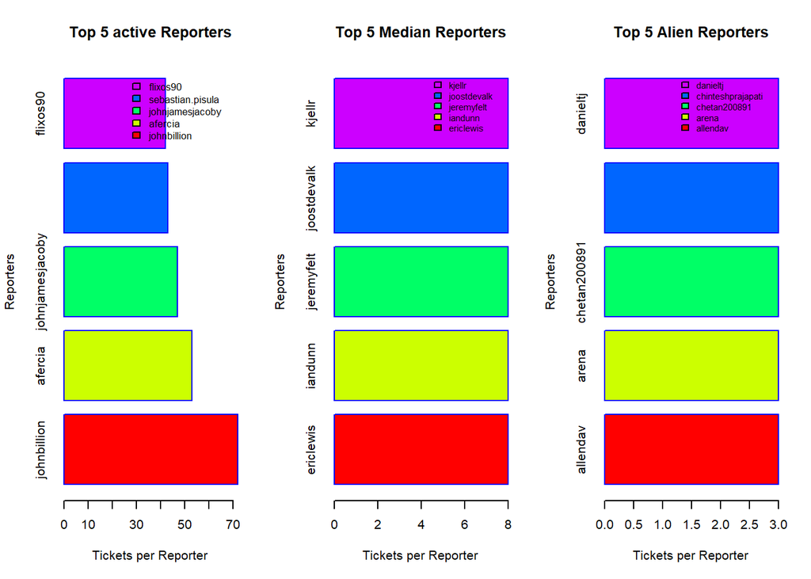

```r
#Grafic of Top 5 active Reporters
par(mfrow=c(1,3))
barplot(RankAR$Freq[1:5],
        names.arg=RankAR$Var1[1:5],
        horiz=TRUE,
        xlab="Tickets per Reporter",
        ylab="Reporters",
        col=rainbow(5),
        main="Top 5 active Reporters",
        border="blue",
        legend.text = RankAR$Var1[1:5],
        args.legend = list("bottom", bty="n", cex = 0.8))#Top 5 Active Reporters

barplot(RankMR$Freq[1:5],
        names.arg=RankMR$Var1[1:5],
        horiz=TRUE,
        xlab="Tickets per Reporter",
        ylab="Reporters",
        col=rainbow(5),
        main="Top 5 Median Reporters",
        border="blue",
        legend.text = RankMR $Var1[1:5],
        args.legend = list("bottom", bty="n", cex = 0.7))#Top 5 Median Reporters

barplot(Ranklr$Freq[1:5],
        names.arg=Ranklr$Var1[1:5],
        horiz=TRUE,
        xlab="Tickets per Reporter",
        ylab="Reporters",
        col=rainbow(5),
        main="Top 5 Alien Reporters",
        border="blue",
        legend.text = Ranklr$Var1[1:5],
        args.legend = list("bottom", bty="n", cex = 0.7))#Top 5 Less acctive Reporters
```

**2.3 Owner Members Analysis Report:** The groups of Owners:

```r
RankAO#Ranking the most active Owners
```

```
##              Var1 Freq
## 6  SergeyBiryukov   67
## 2        audrasjb   18
## 5     johnbillion   16
## 3       chriscct7   15
## 4       joemcgill   14
## 1 adamsilverstein   13
```

```r
RankMO#Ranking the Median Owners
```

```
##              Var1 Freq
## 4         desrosj    9
## 7           nacin    8
## 1         afercia    7
## 3    boonebgorges    7
## 8           pento    7
## 2          azaozz    6
## 5        flixos90    6
## 6      jeremyfelt    6
## 9          rmccue    6
## 10          westi    6
## 11    westonruter    5
## 12 wonderboymusic    5
```

```r
RanklO[c(1:30),c(1:2)]#Ranking the 30 less active Owners
```

```
##                 Var1 Freq
## 12              dd32    3
## 31          joehoyle    3
## 86          tz-media    3
## 93              xkon    3
## 10     davidakennedy    2
## 14          dswebsme    2
## 18         ericlewis    2
## 20   garrett-eclipse    2
## 23       ianbelanger    2
## 26           iseulde    2
## 29           jnylen0    2
## 34       joostdevalk    2
## 38           kapeels    2
## 45       markjaquith    2
```

[output cut: 16 more lines]

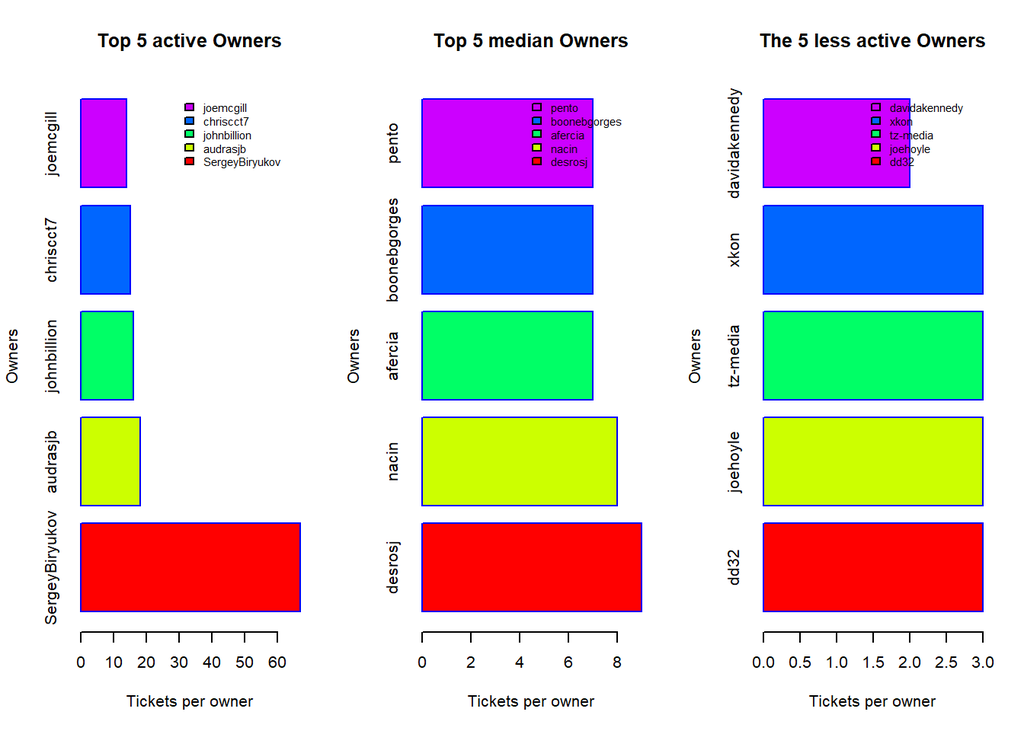

```r
#Grafic of Owners
par(mfrow=c(1,3))
barplot(RankAO$Freq[1:5],
        names.arg=RankAO$Var1[1:5],
        horiz=TRUE,
        xlab="Tickets per owner",
        ylab="Owners",
        col=rainbow(5),
        main="Top 5 active Owners",
        border="blue",
        legend.text = RankAO$Var1[1:5],
        args.legend = list("bottom", bty="n", cex = 0.7))#Top 5 Active Owners

barplot(RankMO$Freq[1:5],
        names.arg=RankMO$Var1[1:5],
        horiz=TRUE,
        xlab="Tickets per owner",
        ylab="Owners",
        col=rainbow(5),
        main="Top 5 median Owners",
        border="blue",
        legend.text = RankMO$Var1[1:5],
        args.legend = list("bottom", bty="n", cex = 0.7))#Top 5 Median Owners

barplot(RanklO$Freq[1:5],
        names.arg=RanklO$Var1[1:5],
        horiz=TRUE,
        xlab="Tickets per owner",
        ylab="Owners",
        col=rainbow(5),
        main="The 5 less active Owners",
        border="blue",
        legend.text = RanklO$Var1[1:5],
        args.legend = list("bottom", bty="n", cex = 0.7))#Top 5 Less Active Owners
```

**2.4 Comparation of groups by Reporters and Owners:**

```r
WPCGroupR #Group Types of Reporters
```

```
##         CoreGroupR MembersTotalR     PropMR
## 1        Reporters          1028 0.50765432
## 2 Active Reporters            34 0.01679012
## 3 Median Reporters            36 0.01777778
## 4  Alien Reporters           927 0.45777778
```

```r
WPCGroupO #Group Types of Owners
```

```
##      CoreGroupO MembersTotalO     PropMO
## 1        Owners           116 0.50877193
## 2 Active Owners             6 0.02631579
## 3 Median Owners            12 0.05263158
## 4  Alien Owners            94 0.41228070
```

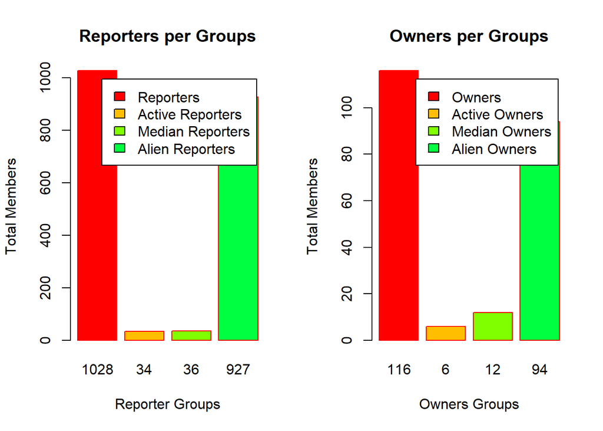

```r
par(mfrow=c(1,2))
barplot(WPCGroupR$MembersTotal,
        names.arg=WPCGroupR$MembersTotal,
        xlab="Reporter Groups",
        ylab="Total Members",
        legend=WPCGroupR$CoreGroupR,
        col=rainbow(8),
        main="Reporters per Groups",border="red")

barplot(WPCGroupO$MembersTotal,
        names.arg=WPCGroupO$MembersTotal,
        xlab="Owners Groups",
        ylab="Total Members",
        legend=WPCGroupO$CoreGroupO,
        col=rainbow(8),
        main="Owners per Groups",border="red")
```

**3. POTENTIAL INDICATORS:**

- The “Sense of Unity” Dimension indicator:
  - Mode_Agents_Rules: In a scale from O to 1, this indicator represents the principals rules the WP members play in the community: active, median and alien. This unformal rules are observed into formal groups: owners and reporters. The Hypothesis is that the Reporters Group and the Owners Group have a similar distribution of tickets per its the respectives sub groups(active, median, and alien).

Hypothesis: $PropMo = PropMR$

Means: percentual of tickets into any subgroups into Owner Groups are similar thand percentual of tickets into any subgroups into Reporter Groups

Hypothesis test:

```r
similarityOR<-ifelse(PropMO>PropMR,1-(PropMO-PropMR),1-(PropMR-PropMO))
similarityOR<-mean(similarityOR)
similarityOR
```

```
## [1] 0.9772515
```

Thus, Mode_Agents_Rules indicator is = similarityOR.

**4. FINAL CONCLUSIONS:**

The hypothesis test proof (result: 0.9772515) indicates that there are a strong coesion into formals groups of core: owners and reporters.

Despite the most of tickets have no owner, there are not so many urgent issues. Around 93% of tickets are classified as Severity “normal”, and 97% are classified as Priority “Normal”.

According with this description, are recommended analyse in a bivariable description the folow variables:

- Variables for setup a referential of the community (The “Referentiality” Dimension): Documentation of values, general view and beiefs of community
- Variables for analyse the “Prescritivity” dimension: Analyse the community referential with “Focuses” Variable, in order to verify if the members produced what they stablished into referential.
- Variables for analyse the “Sense of Unity” dimension: “Keywords” Variable, in order to verify the correlation with groups
- Variables for analyse the the “Receptivity” dimension: Groups of members, correlation between groups and Status, Type, Milestone variables